# Эконометрика #1

Mikhail Plekhanov

13.04.2015

## Эконометрика на одном слайде

Вопросы:

- Как устроен мир? Как переменная $x$ влияет на переменную $y$?
- Что будет завтра? Как спрогнозировать переменную $y$?

Ответы на эти вопросы мы получаем с помощью моделей.

**Модель** - формула для объясняемой переменной.

Например: $y_{i} = \beta_{1} + \beta_{2}x_{i} + \epsilon_{i}$

## Основные типы данных

- временные ряды
- перекрестные данные
- панельные данные

Временные ряды:

| Год | Население (тыс. чел.) | Безработица (%) |
| --- | --- | --- |
| 2010 | 142962 | 7.4 |
| 2011 | 142914 | 6.5 |
| 2012 | 143103 | 5.5 |
| 2013 | 143395 | 5.5 |

Панельные данные - сочетание первых двух.

## Данные - обозначения

- одна зависимая (объясняемая) переменная: $y$
- несколько регрессоров (объясняющих переменных): $x$, $z$…
- по каждой переменной $n$ наблюдение: $y_1$, $y_2$, … , $y_n$

## Данные - пример

Исторические данные 1920-x годов

```
##   speed dist
## 1     4    2
## 2     4   10
## 3     7    4
## 4     7   22
## 5     8   16
## 6     9   10
```

## Всегда изображайте данные!

Никакой эконометрический анализ не заменит простого графического анализа. Вы можете выявить простым графическим анализом то, что выявить вслепую без графиков эконометрически очень сложно.

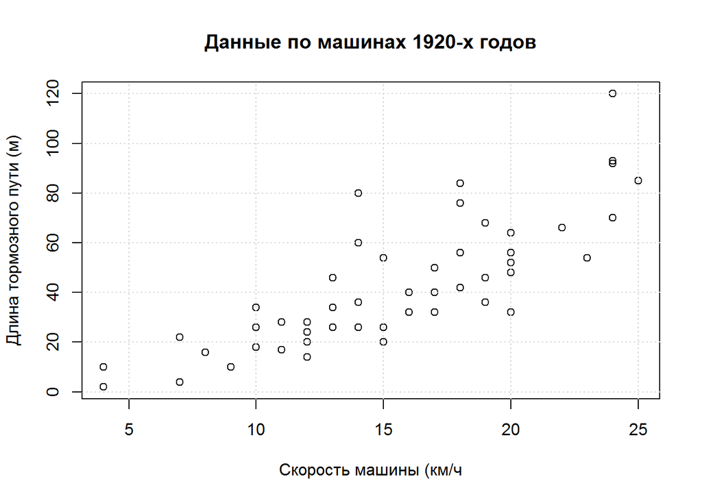

Видим, чем больше скорость, тем больше длина тормозного пути.

## Модель

Пример: $y_{i} = \beta_{1} + \beta_{2}x_{i}+\epsilon_{i}$

- наблюдаемы переменные: $y$, $x$
- неизвестные параметры: $\beta_1$, $\beta_2$
- случайная составляющая, ошибка: $\epsilon$

План действий:

- построить адекватную модель
- получить оценки неизвестных параметров: $\hat{\beta_{1}}$, $\hat{\beta_{2}}$
- прогнозировать, заменив неизвестные параметры на оценки: $\hat{y_{i}} = \hat{\beta_{1}} + \hat{\beta_{2}}$

## Метод наименьших квадратов

Это способ получить оценки неизвестных параметров модели, исходя из реальных данных. Если мы получили какие-то оценки $\hat{\beta_{1}}$, $\hat{\beta_{2}}$, то естественно у нас возникает такое понятие как *ошибка прогноза*:

$\hat{\epsilon_{i}} = y_{i} - \hat{y_{i}}$

$\hat{\epsilon_{i}}$ - это разница между фактическим наблюдением $y_{i}$ и прогнозом $\hat{y_{i}}$.

И, естесственно, возникает суммарная ошибка прогноза. Чтобы ошибки не компенсировали друг друга, возведем их в квадрат и посчитаем *сумму квадратов ошибок прогноза*:

$Q(\hat{\beta_{1}}, \hat{\beta_{2}}) = \sum\limits_{i=1}^n \hat{\epsilon_{i}}^2 = \sum\limits_{i=1}^n (y_{i} - \hat{y_{i}})^2$

Суть МНК: возьмите в качестве оценок такие $\hat{\beta_{1}}$, $\hat{\beta_{2}}$, при которых сумма квадратов ошибок прогноза $Q$ минимальна.

# Примеры

## Пример 1. Регрессия на константу.

```r
# вес, кг
y <- c(60, 70, 80)
# рост, см
x <- c(170, 170, 181)
```

Оценим 2 модели:

M1: $y_{i} = \beta + \epsilon_{i}$

M2: $y_{i} = \beta_{1} + \beta_{2}x_{i}+\epsilon_{i}$

МНК - минимизировать величину RSS:

$\min\sum\limits_{i=1}^n \hat{\epsilon_{i}}^2 = \min\sum\limits_{i=1}^n (y_{i} - \hat{y_{i}})^2$

**M1**: $\hat{y_{i}} = \hat{\epsilon}$, следовательно

$\sum\limits_{i=1}^3 (y_{i} - \hat{y_{i}})^2 = \sum\limits_{i=1}^3 (y_{i} - \hat{\beta})^2 = Q(\hat{\beta}) = \sum\limits_{i=1}^3 (y_{i}^2 - 2y_{i}\hat{\beta} + \hat{\beta}^2) = \sum\limits_{i=1}^3 y_{i}^2 - \sum\limits_{i=1}^3 2y_{i}\hat{\beta} + \sum\limits_{i=1}^3\hat{\beta}^2$

$\sum\limits_{i=1}^3\hat{\beta}^2 = 3\hat{\beta}^2$ (В общем случае $n\hat{\beta}^2)$

$\sum\limits_{i=1}^n 2y_{i}\hat{\beta} = 2\hat{\beta}\sum\limits_{i=1}^n y_{i}$

$Q(\hat{\beta}) = \sum\limits_{i=1}^n y_{i}^2 - 2\hat{\beta}\sum\limits_{i=1}^n y_{i} + n\hat{\beta}^2$

$Q'(\hat{\beta}) = - 2\sum\limits_{i=1}^n y_{i} + 2n\hat{\beta}$

$\hat{\beta} = \sum\limits_{i-1}^n \frac{y_{i}}{n} = \bar{y}$

Таким образом: $\hat{\beta}_{МНК} = \frac{60+70+80}{3} = 70$

## Пример 2. Парная регрессия.

Заметим, что $\frac{\sum\limits_{i=1}^n x_{i}}{n} = \bar{x}$ Отсюда следует, что $\sum\limits_{i=1}^n x_{i} = n\bar{x} = \sum\limits_{i=1}^n \bar{x}$ и, $\sum\limits_{i=1}^n (x_{i} - \bar{x}) = 0$

**M2**: $y_{i} = \hat{\beta_{1}} + \hat{\beta_{2}}x_{i}$

$RSS = \sum\limits_{i=1}^n (y_{i} - \hat{y_{i}})^2 = \sum\limits_{i=1}^n (y_{i} - \hat{\beta_{1}} - \hat{\beta_{2}}x_{i})^2 = Q(\hat{\beta_{1}}, \hat{\beta_{2}})$

Получаем: $\hat{\beta_{1}} = \bar{y} - \hat{\beta_{2}}\bar{x}$ $\hat{\beta_{2}} = \frac{\sum\limits_{i=1}^n (y_{i} - \bar{y})(x_{i}-\bar{x})}{\sum\limits_{i=1}^n (x_{i}-\bar{x})^2}$

```r
beta2 = sum((y - mean(y))*(x - mean(x)))/sum((x-mean(x))^2)
beta1 = mean(y) - beta2*mean(x)
```

Получили, $\hat{\beta_{1}} = -166.8181818$ и $\hat{\beta_{2}} = 1.3636364$

# Суммы квадратов

Сумма квадратов остаткой - Residual Sum of Squares:

$RSS = \sum \hat{\epsilon_{i}}^2$

RSS показывает величину ошибки прогноза.

Общая сумма квадратов - Total Sum of Squares:

$TSS = \sum (y_{i} - \bar{y})^2$

TSS показывает, насколько каждый из $y_{i}$ не похож на среднее значение $\bar{y}$.

Объясненная сумма квадратов - Explained Sum of Squares:

$ESS = \sum (\hat{y_{i}} - \bar{y})^2$

# Коэффициент детерминации - простой показатель качества

$TSS = RSS + ESS$

Коэффициент детерминации $R^2 \in [0;1]$ $R^2 = \frac{ESS}{TSS}$ доля объяснённого разброса y в общем разбросе y.

**Теорема** Если в регрессию включён свободный член $(y_i=\beta_i + ...)$ и оценки МНК единственны, то $R^2$ равен квадрату выборочной корреляции между $y$ и $\hat{y}$, т.е.

$R^2 = (sCorr(y,\hat{y}))^2 = \Bigg(\frac{\sum (y_i - \bar{y})(\hat{y}_i - \bar{y})}{\sqrt{\sum (y_i - \bar{y})^2}\sqrt{\sum (\hat{y}_i - \bar{y})^2}}\Bigg)^2$